# Project 2: Sunday Data

## Introduction:

In this project I will be using the `OnlineNewsPopularity.csv` data, which is a data set about various articles that are published along with various article and publishing attributes. The goal of this project is to accurately predict the number of times that a particular article will be "shared" on social media given its attributes.

## Data Summary

Overall, the Online News Popularity data has *39644* observations and *62* variables. There are a total of *2737* observations for articles that were published on a Sunday, and that is the subset of observations that I will be using for this report. From the initial variables, I will be considering *46* of them as potentially having an effect on number of shares.

There are 5 groups of variables that have similar themes in this data set. The variables within each group likely have high correlations with each other. The variable groups are about:

1. Number of words/keywords/media
2. Digital channel type
3. Shares by keyword
4. Typical shares of articles in Mashable
5. Sentiment and Polarity

**Correlation Plots for Number of Word Variables:**

As seen below, many of the variables are highly correlated and might need to be removed.

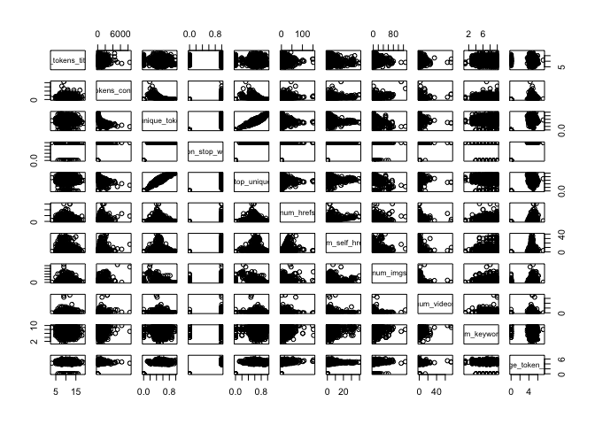

**Shares by Keyword Variables:**

As seen below, many of the variables seem correlated and might need to be removed.

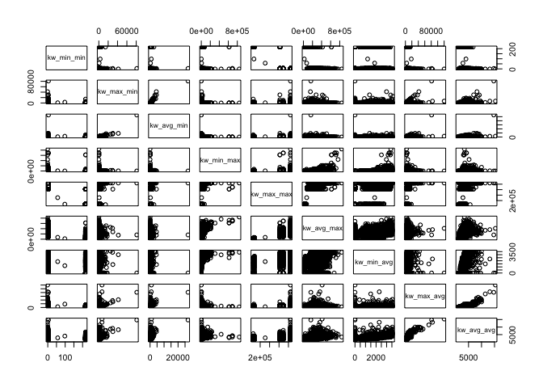

**Mashable Shares Variables:**

These variables seem to have very similar distributions. It is not clear whether there will be any relationship with overall shares.

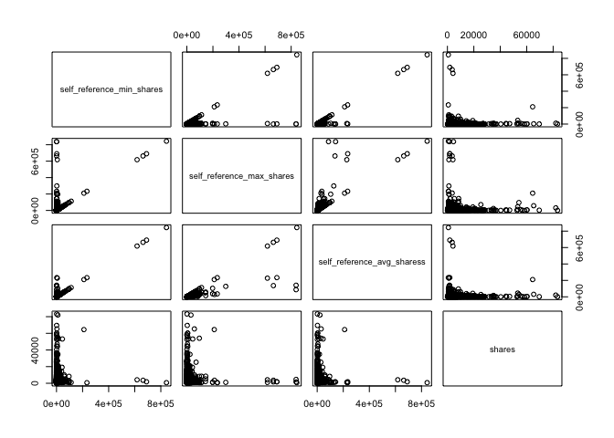

**Sentiment/Polarity Variables:**

When comparing variables measuring positive and negative polarities, there seems to be moderate to strong correlations.

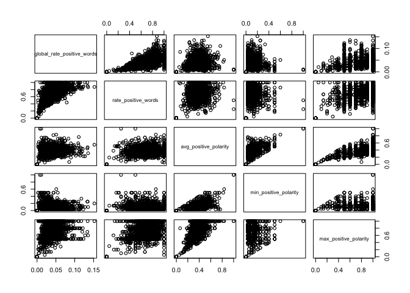

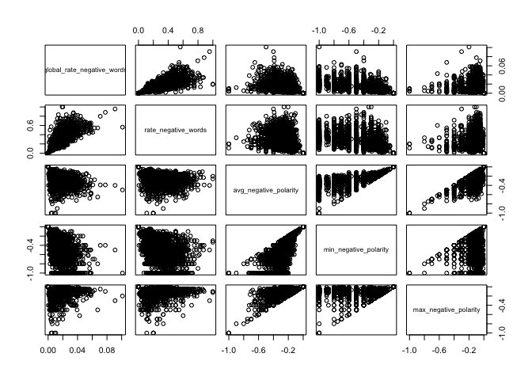

## Modeling

First, I will split the data into training and test sets. The training data set will contain 70% of the data observations, and the test set will contain the remaining 30%.

Dimensions of the train and test sets:

```
## [1] 1915   46

## [1] 822  46
```

### Linear Model

I will first begin by fitting a linear regression model with ALL of the variables.

```
##
## Call:
## lm(formula = shares ~ ., data = dTrain)
##
## Residuals:
##    Min     1Q Median     3Q    Max
##  -8405  -2406  -1141    263  78918
##
## Coefficients: (1 not defined because of singularities)
##                                 Estimate Std. Error t value Pr(>|t|)
## (Intercept)                   -2.905e+03  1.937e+03  -1.500 0.133869
## n_tokens_title                 1.247e+02  6.943e+01   1.795 0.072739 .
## n_tokens_content               2.954e-01  4.317e-01   0.684 0.493835
## n_unique_tokens                7.643e+03  4.329e+03   1.766 0.077640 .
## n_non_stop_words               2.327e+03  3.882e+03   0.599 0.549069
## n_non_stop_unique_tokens      -4.082e+03  3.767e+03  -1.084 0.278723
## num_hrefs                      1.366e-01  1.545e+01   0.009 0.992949
## num_self_hrefs                -2.614e+01  3.521e+01  -0.742 0.457916
## num_imgs                       1.131e+01  1.866e+01   0.606 0.544645
## num_videos                     4.582e+01  4.368e+01   1.049 0.294354
## average_token_length          -7.538e+02  5.412e+02  -1.393 0.163850
## num_keywords                   1.035e+02  9.199e+01   1.125 0.260617
## data_channel_is_lifestyle     -2.480e+02  6.586e+02  -0.377 0.706534
## data_channel_is_entertainment  3.609e+02  5.420e+02   0.666 0.505557
## data_channel_is_bus            1.247e+03  6.381e+02   1.954 0.050877 .
## data_channel_is_socmed         1.530e+03  7.552e+02   2.026 0.042922 *
## data_channel_is_tech           1.247e+03  6.113e+02   2.040 0.041512 *
## data_channel_is_world          2.572e+02  6.557e+02   0.392 0.694923
## kw_min_min                     5.022e+00  3.757e+00   1.337 0.181388
## kw_max_min                     2.968e-01  2.046e-01   1.451 0.147075
## kw_avg_min                    -1.831e+00  1.341e+00  -1.365 0.172324
## kw_min_max                    -1.229e-03  3.833e-03  -0.321 0.748522
## kw_max_max                     9.481e-04  1.412e-03   0.671 0.502047
## kw_avg_max                    -1.878e-03  2.289e-03  -0.821 0.411928
## kw_min_avg                    -7.007e-01  1.811e-01  -3.869 0.000113 ***
## kw_max_avg                    -2.734e-01  6.547e-02  -4.176 3.10e-05 ***
## kw_avg_avg                     2.035e+00  3.530e-01   5.765 9.51e-09 ***
## self_reference_min_shares      6.721e-04  2.469e-02   0.027 0.978290
## self_reference_max_shares     -2.809e-03  7.979e-03  -0.352 0.724813
## self_reference_avg_sharess     5.954e-03  3.127e-02   0.190 0.849022
## global_subjectivity           -4.979e+01  1.991e+03  -0.025 0.980051
## global_sentiment_polarity      9.067e+03  3.913e+03   2.317 0.020614 *
## global_rate_positive_words    -2.946e+04  1.546e+04  -1.906 0.056818 .
## global_rate_negative_words    -1.427e+04  3.475e+04  -0.411 0.681401
## rate_positive_words           -2.019e+03  2.835e+03  -0.712 0.476468
## rate_negative_words                   NA         NA      NA       NA
## avg_positive_polarity         -9.162e+02  3.306e+03  -0.277 0.781688
## min_positive_polarity         -3.083e+03  2.655e+03  -1.161 0.245685
## max_positive_polarity         -4.768e+01  1.096e+03  -0.044 0.965305
## avg_negative_polarity         -1.633e+03  2.964e+03  -0.551 0.581721
## min_negative_polarity         -9.756e+02  1.073e+03  -0.910 0.363161
## max_negative_polarity          2.065e+03  2.428e+03   0.851 0.395014
## title_subjectivity             1.642e+03  6.840e+02   2.401 0.016470 *
## title_sentiment_polarity      -1.251e+02  5.712e+02  -0.219 0.826677
## abs_title_subjectivity         2.128e+03  8.728e+02   2.438 0.014866 *
## abs_title_sentiment_polarity  -8.364e+02  9.345e+02  -0.895 0.370875
## ---
## Signif. codes:  0 '***' 0.001 '**' 0.01 '*' 0.05 '.' 0.1 ' ' 1
##
## Residual standard error: 6114 on 1870 degrees of freedom
## Multiple R-squared:  0.0631, Adjusted R-squared:  0.04106
## F-statistic: 2.862 on 44 and 1870 DF,  p-value: 1.949e-09
```

```
##
## Call:
## lm(formula = shares ~ data_channel_is_entertainment + kw_min_min +
##     kw_max_max + kw_avg_max + kw_max_avg + kw_avg_avg + min_positive_polarity,
##     data = dTrain)
##
## Residuals:
##    Min     1Q Median     3Q    Max
##  -7547  -2335  -1484     68  80197
##
## Coefficients:
##                                 Estimate Std. Error t value Pr(>|t|)
## (Intercept)                    1.445e+01  1.136e+03   0.013   0.9899
## data_channel_is_entertainment  2.084e+02  3.602e+02   0.579   0.5630
## kw_min_min                     4.799e+00  3.705e+00   1.295   0.1953
## kw_max_max                     1.008e-03  1.347e-03   0.748   0.4544
## kw_avg_max                    -1.671e-03  1.620e-03  -1.031   0.3025
## kw_max_avg                    -1.169e-01  5.161e-02  -2.266   0.0236 *
## kw_avg_avg                     1.227e+00  2.239e-01   5.478 4.87e-08 ***
## min_positive_polarity         -1.134e+03  1.834e+03  -0.618   0.5364
## ---
## Signif. codes:  0 '***' 0.001 '**' 0.01 '*' 0.05 '.' 0.1 ' ' 1
##
## Residual standard error: 6176 on 1907 degrees of freedom
## Multiple R-squared:  0.02528,    Adjusted R-squared:  0.0217
## F-statistic: 7.066 on 7 and 1907 DF,  p-value: 2.376e-08
```

Looking at the plots for the model, it seems that there are leverage points affecting the predictions.

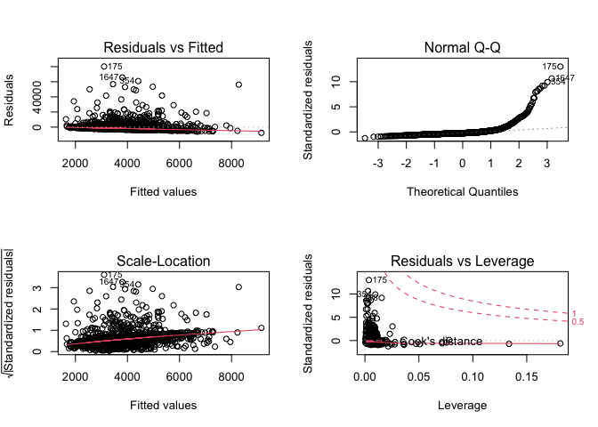

```
##
## Call:
## lm(formula = shares ~ data_channel_is_entertainment + kw_min_min +
##     kw_max_max + kw_avg_max + kw_max_avg + kw_avg_avg + min_positive_polarity,
##     data = dTrain, weights = as.numeric(w))
##
## Weighted Residuals:
##     Min      1Q  Median      3Q     Max
## -4282.4 -1514.4  -825.5   447.4 18717.1
##
## Coefficients:
##                                 Estimate Std. Error t value Pr(>|t|)
## (Intercept)                    1.217e+03  5.297e+02   2.298 0.021664 *
## data_channel_is_entertainment  3.872e+01  1.665e+02   0.232 0.816209
## kw_min_min                    -1.825e-01  1.724e+00  -0.106 0.915691
## kw_max_max                     4.998e-04  6.280e-04   0.796 0.426190
## kw_avg_max                    -3.012e-03  7.610e-04  -3.958 7.84e-05 ***
## kw_max_avg                    -7.377e-02  3.171e-02  -2.326 0.020117 *
## kw_avg_avg                     8.561e-01  1.106e-01   7.740 1.63e-14 ***
## min_positive_polarity         -3.091e+03  8.931e+02  -3.460 0.000552 ***
## ---
## Signif. codes:  0 '***' 0.001 '**' 0.01 '*' 0.05 '.' 0.1 ' ' 1
##
## Residual standard error: 2801 on 1838 degrees of freedom
## Multiple R-squared:  0.05243,    Adjusted R-squared:  0.04882
## F-statistic: 14.53 on 7 and 1838 DF,  p-value: < 2.2e-16
```

### Non-Linear Models

First, I will fit a simple Regression Tree in order to predict shares. Here is the code below:

```r
set.seed(100)
trctrl <- trainControl(method="repeatedcv", number=10, repeats = 3)
metric = 'RMSE'
tree_fit <- train(shares ~., data = dTrain, method = "rpart", metric = metric, trControl = trctrl,
                 preProcess = c("center", "scale") )
```

I will also fit a bagged tree to predict shares. Here is the code for that:

```r
bag_fit <- train(shares ~., data = dTrain, method = "treebag", metric = metric, trControl = trctrl,
                 preProcess = c("center", "scale") )
```

## Test Set Prediction

I will fit each of the 3 models (Linear Regression, Regression Tree, Bagged Tree) on the test data set.

Here are the corresponding RMSE values:

- The RMSE for the Linear Regression model on the test set is 6120.7987846.
- The RMSE for the Regression Tree model on the test set is 6146.8241442.
- The RMSE for the Bagged Tree model on the test set is 6143.6147571.

## Conclusion

Comparing the linear and non-linear methods based on test MSE, the Linear Regression model performed the best in predicting number of shares, despite having a high MSE and low adjusted R<sup>2</sup> on its own.